# CURSO DE R PARA ANÁLISE DE DADOS - Inferência Causal

# INTRODUÇÃO

# Causalidade

[figure not shown]

Tidymodels é um conjunto de bibliotecas que cuida de todos os passos necessários para desenvolver o workflow de seleção e avaliação de modelos de aprendizado estatístico.

O desenvolvimento é financiado pela RStudio e liderado por Max Kuhn, o principal desenvolvedor de uma biblioteca similar mais antiga: caret.

A tidymodels é toda tidy friendly. Essa é uma das diferenças em relação à caret. Ela também é mais completa e possui muito mais funcionalidades.

É possível obter mais informações em [tidymodels.org](https://www.tidymodels.org/)

# Inferência Causal

É a área de conhecimento que desenvolve métodos para estimar o impacto de eventos e decisões em desfechos de interesse. Isso é feito partindo de um conhecimento tácito a respeito do contexto.

# Correlação x Causalidade

banco central, ladeira, barco a vela

# Dados Experimentais x Dados Observacionais

# PROBABILIDADE E REGRESSÃO

# Experimento aleatório

Um evento sobre cujo desfecho temos incerteza.

Experimento que ao ser repetido sob as mesmas condições observáveis não produz sempre o mesmo resultado.

- Lançamento de dado
- Sorteio de bolinhas azuis e vermelhas de uma urna
- Sexo de uma criança ao nascer
- Peso de uma criança ao nascer
- Lançamentos de dardo em sequência por um atleta
- Tempo de vida útil de uma lâmpada

# Espaço amostral

Espaço amostral é o conjunto de resultados possíveis

Experimentos discretos, onde o espaço amostral é enumerável (pode ser colocado em correspondência biunívoca com o conjunto dos naturais):

- Lançamento de um dado: $\Omega = \{1, 2, 3, 4 ,5 ,6\}$
- Sorteio de bolinhas: $\Omega = \{ azul, vermelha \}$
- Sexo de uma criança ao nascer: $\Omega = \{masculino, feminino\}$

Experimentos contínuos, onde o espaço amostral é não-enumerável:

- Peso de uma criança ao nascer: $\Omega = \{x \in \mathbb{R}, x \geq 0 \}$
- Lançamentos de dardo em sequência por um atleta: $\Omega = \{x: x \in \mathbb{R}, x \geq 0 \}$
- Tempo de vida útil de uma lâmpada: $\Omega = \{x: x \in \mathbb{R}, x \geq 0 \}$

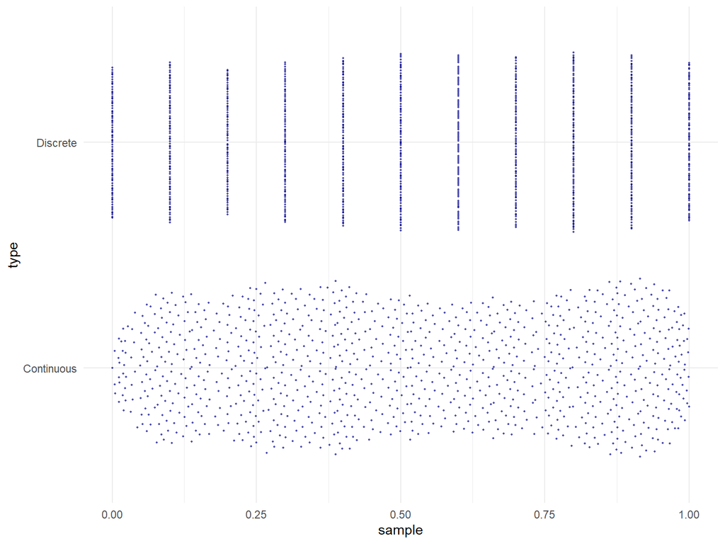

```r
samples <- tibble(
  sample = runif(n = 1000, min = 0, max = 1 ),
  type = "Continuous"
) %>%
  bind_rows(
    tibble(
      sample = sample(x = seq(0, by = 0.1, to = 1 ), size = 1000, replace = TRUE ),
      type = "Discrete"
    )
  )


ggplot(samples) +
  geom_quasirandom(
    aes(
      x = sample,
      y = type,
    ),
    color = "darkblue",
    size = 0.3,
    alpha = 0.6,
    groupOnX =  FALSE
  ) +
  theme_minimal()
```

# Probabilidade

Probabilidades resultam de uma distribuição do montante de uma unidade (um montante 1) pelos possíveis eventos do espaço amostral.

Um evento é definido por um subconjunto do espaço amostral.

Um evento simples é representado por um único elemento do espaço amostral

Um evento A do espaço amostral relativo ao lançamento de um dado pode ser definido como o equivalente a um dado ficar com a face 6 voltada para cima após o lançamento. Neste caso $A = \{6\}$

Um evento B pode ser definido como um lançamento resultar em um número par. Neste caso $B = \{2, 4, 6\}$

No caso de um dado, é claro que cada evento simples possível deve receber uma parte igual do “orçamento” de 1. Portanto a probabilidade de cada evento simples é 1/6. $P(A) = \frac{1}{6}$.

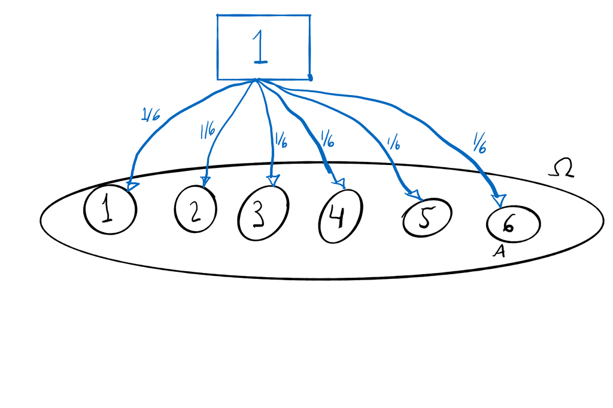

No caso de um espaço amostral contínuo, acontece o mesmo, a unidade é dividida nos elementos do espaço amostral, mas agora conjunto tem infinitos elementos não enumeráveis.

Um evento definido neste espaço engloba um intervalo de pontos. Por exemplo, o evento pode ser o nascimento de crianças de mais de 4kg.

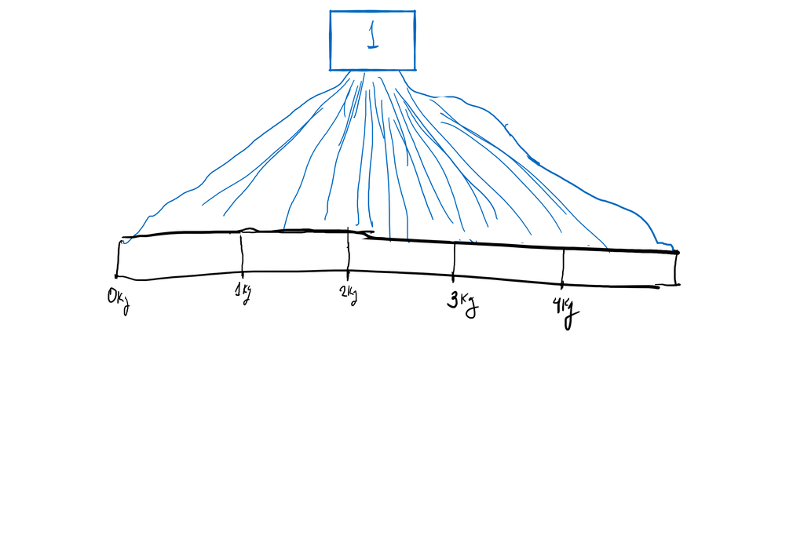

As probabilidades seguem os seguintes axiomas:

- $P(\Omega) = 1$
- Para todo conjunto A, $P(A) \geq 0$
- Para toda sequência de eventos mutuamente exclusivos $A_1, A_2, ...$ temos $P\left ( \bigcup_{i = 1}^{\infty} A_i\right ) = \sum_{i=1}^\infty \left (P(A_i) \right )$, ou seja, a probabilidade da união de eventos mutuamente exclusivos é igual à soma da probabilidade desses eventos.

Esta é uma definição axiomática, que não fala sobre o significado do valor de probabiidade distribuído pelos elementos.

Queremos um número que reflita a chance de ocorrência de cada evento.

Esse número pode ser pensado a partir de uma abordagem frequentista, onde a probabilidade é estimada a partir da frequência de ocorrência do evento em um número grande de execuções conhecidas e independentes do experimento aleatório: $f_{}n,a = \frac{n(A)}{n}$

Entretanto, nem sempre é possível conhecer um número grande desfechos para o evento aleatório nas mesmas condições. Neste caso, podemos adotar valores baseados na crença que temos na ocorrência de cada evento.

# Probabilidade Condicional

O conceito de probabilidade condicional é importantíssimo.

A probabilidade condicional funciona como uma possível restrição ao espaço amostral de um evento B pela ocorrência de um evento A.

Podemos exemplificar pelo espaço amostral dado pelo resultado do lançamento de um par de dados

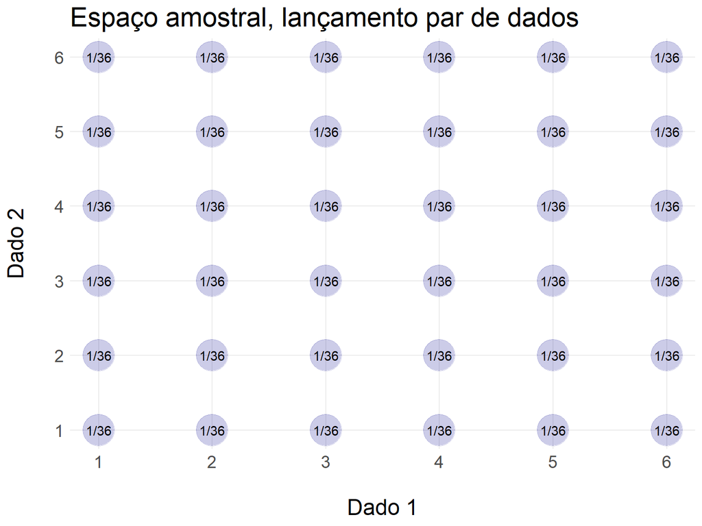

```r
desfecho_par_dados <- tibble(
  dado_1 = 1L:6L
) %>%
  crossing(
    tibble(
      dado_2 = 1L:6L
    )
  )


espaco <- ggplot(desfecho_par_dados) +
  geom_point(
    aes(
      x = dado_1,
      y = dado_2
    ),
    size = 12,
    shape = 21,
    color = "darkblue",
    fill = "darkblue",
    alpha = 0.2
  ) +
  geom_text(
    aes(
      x = dado_1,
      y = dado_2,
      label = "1/36"
    )
  ) +
  scale_x_continuous(
    breaks = 1:6,
    minor_breaks = NULL
  ) +
  scale_y_continuous(
    breaks = 1:6,
    minor_breaks = NULL
  ) +
  theme_minimal() +
  theme(
    text = element_text(size = 18)
  ) +
  labs(
    x = "\nDado 1",
    y = "Dado 2\n"
  ) +
  ggtitle(
    "Espaço amostral, lançamento par de dados"
  )


espaco
```

Podemos imaginar o seguinte evento:

A: em cada lançamento o valor do dado é menor ou igual a dois

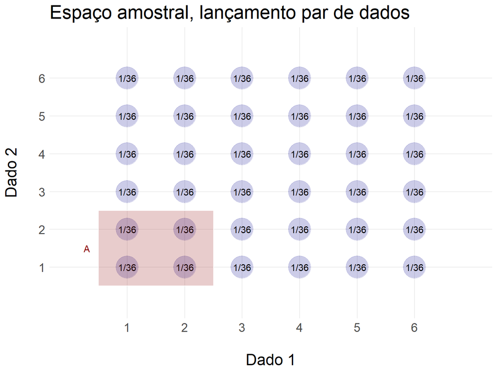

```r
grafico_a <- ggplot(desfecho_par_dados) +
  geom_point(
    aes(
      x = dado_1,
      y = dado_2
    ),
    size = 12,
    shape = 21,
    color = "darkblue",
    fill = "darkblue",
    alpha = 0.2
  ) +
  geom_text(
    aes(
      x = dado_1,
      y = dado_2,
      label = "1/36"
    )
  ) +
  scale_x_continuous(
    breaks = 1:6,
    minor_breaks = NULL,
    limits = c(0,7)
  ) +
  scale_y_continuous(
    breaks = 1:6,
    minor_breaks = NULL,
    limits = c(0,7)
  ) +
  theme_minimal() +
  theme(
    text = element_text(size = 18)
  ) +
  labs(
    x = "\nDado 1",
    y = "Dado 2\n"
  ) +
  ggtitle(
    "Espaço amostral, lançamento par de dados"
  ) +
  annotate(
    "rect",
    xmin = 0.5,
    xmax = 2.5,
    ymin = 0.5,
    ymax = 2.5,
    color = "white",
    fill = "darkred",
    alpha = 0.2
  ) +
  annotate(
    x = 0.3,
    y = 1.5,
    geom = "text",
    label = "A",
    color = "darkred"
  )

grafico_a
```

Podemos definir também outro evento:

B = a soma dos lançamentos é 4

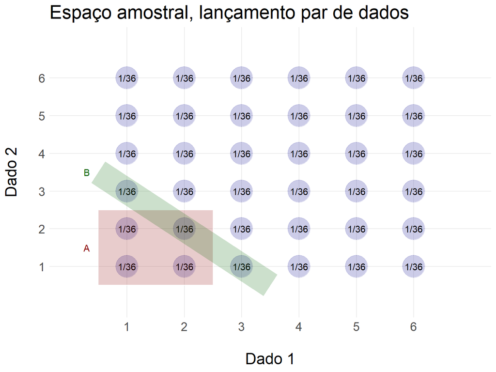

```r
grafico_a_b <- grafico_a +
  annotate(
    geom = "segment",
    x = 3.5,
    y = 0.5,
    xend = 0.5,
    yend = 3.5,
    color = "darkgreen",
    size = 14,
    alpha = 0.2
  ) +
  annotate(
    x = 0.3,
    y = 3.5,
    geom = "text",
    label = "B",
    color = "darkgreen"
  )

grafico_a_b
```

Neste caso as probabilidades dos eventos são essas:

$$P(A) = \frac{4}{36} = \frac{1}{9}$$

$$P(B) = \frac{3}{36} = \frac{1}{12}$$

Se quisermos calcular a probabilidade do evento B dado que o evento A ocorreu, ou seja $P(B|A)$, precisamos considerar que partimos de um novo espaço amostral: o espaço amostral onde A acontece.

Ou seja:

$$P(B|A) = \frac{P(A,B)}{P(A)}$$

# Eventos independentes

Dois eventos são independentes quando a ocorrência de um evento não muda a probabilidade de ocorrência do outro evento. Ou seja: $P(A) = P(A|B)$

Os eventos relacionados ao lançamento de um segundo dado são independentes dos eventos correspondentes ao lançamento do primeiro dado.

Se considerarmos os eventos A = dado 1 deu resultado 6 e B = dado 2 deu resultado 6, eles são independentes.

Um evento não restringe o espaço amostral do outro evento

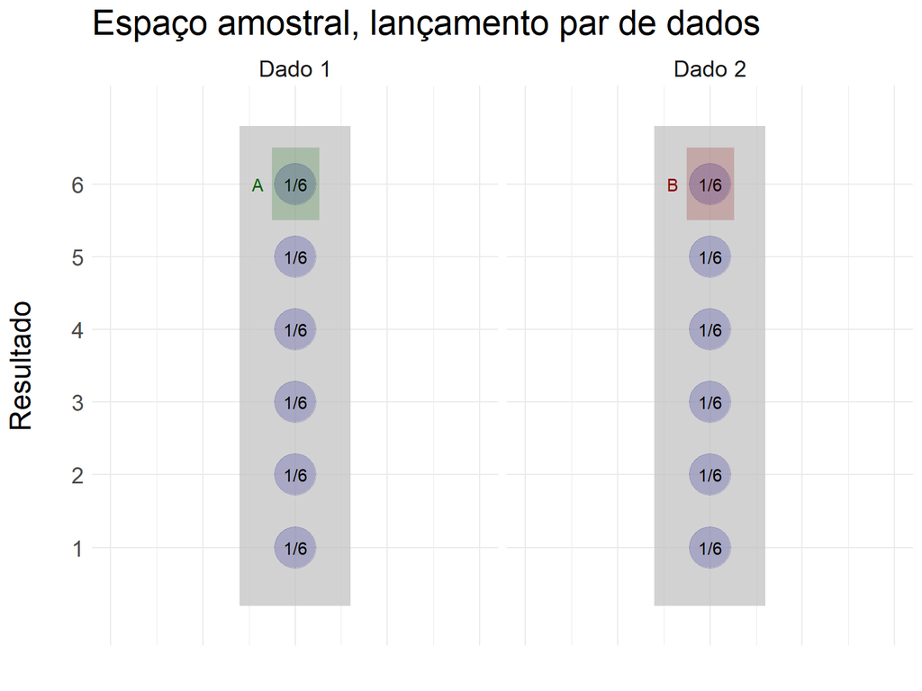

```r
espaço_amostral_independentes = tibble(resultado = 1:6 ) %>%
  crossing(
    dado = c("Dado 1", "Dado 2")
  )


grafico_independentes <- ggplot(espaço_amostral_independentes) +
  geom_rect(
    data = tibble(
      xmin = 0.7,
      ymin = 0.2,
      ymax = 6.8,
      xmax = 1.3,
      dado = c("Dado 2", "Dado 1")
    ),
    aes(
      xmin = xmin,
      ymin = ymin,
      xmax = xmax,
      ymax = ymax,
    ),
    fill = "gray",
    size = 14,
    alpha = 0.7
  ) +
  geom_point(
    aes(
      x = 1,
      y = resultado
    ),
    size = 12,
    shape = 21,
    color = "darkblue",
    fill = "darkblue",
    alpha = 0.2
  ) +
  geom_text(
    aes(
      x = 1,
      y = resultado,
      label = "1/6"
    )
  ) +
  scale_y_continuous(
    breaks = 1:6,
    minor_breaks = NULL,
    limits = c(0,7)
  ) +
  scale_x_continuous(
    limits = c(0,2)
  ) +
  theme_minimal() +
  theme(
    text = element_text(size = 18)
  ) +
  ggtitle(
    "Espaço amostral, lançamento par de dados"
  ) +
  geom_segment(
    data = tibble(
      x = 1,
      y = 5.5,
      xend = 1,
      yend = 6.5,
      dado = "Dado 1"
    ),
    aes(
      x = x,
      xend = xend,
      y = y,
      yend = yend
    ),
    color = "darkgreen",
    size = 14,
    alpha = 0.2
  ) +
  geom_segment(
    data = tibble(
      x = 1,
      y = 5.5,
      xend = 1,
      yend = 6.5,
      dado = "Dado 2"
    ),
    aes(
      x = x,
      xend = xend,
      y = y,
      yend = yend
    ),
    color = "darkred",
    size = 14,
    alpha = 0.2
  ) +
  facet_wrap(
    ~dado
  ) +
  theme(
    axis.text.x = element_blank()
  ) +
  labs(
    x = "",
    y = "Resultado\n"
  ) +
  geom_text(
    data = tibble(
      x = 0.8,
      y = 6,
      dado = "Dado 1"
    ),
    aes(
      x = x,
      y = y
    ),
    color = "darkgreen",
    label = "A"
  ) +
  geom_text(
    data = tibble(
      x = 0.8,
      y = 6,
      dado = "Dado 2"
    ),
    aes(
      x = x,
      y = y
    ),
    color = "darkred",
    label = "B"
  ) +
  facet_wrap(
    ~dado
  ) +
  theme(
    axis.text.x = element_blank()
  ) +
  labs(
    x = "",
    y = "Resultado\n"
  )



grafico_independentes
```

Como

$$P(B|A) = \frac{P(A,B)}{P(A)}$$
,

então:

$$P(A,B) = P(A) P(B|A)$$